# Risk Modelling for Assaults in Chicago

Jie Li

10/24/2021

```r
library(tidyverse)
library(sf)
library(RSocrata)
library(viridis)
library(spatstat)
library(raster)
library(spdep)
library(FNN)
library(grid)
library(gridExtra)
library(knitr)
library(kableExtra)
library(tidycensus)
library(gtable)
library(ggpubr)

setwd("C:/Users/leeje/OneDrive/G-1/CPLN-592/Codes/Assignment 3")
census_api_key("c16daad4da8c67d74b58b082c036a84ba5a7d861", overwrite = TRUE)
root.dir = "https://raw.githubusercontent.com/urbanSpatial/Public-Policy-Analytics-Landing/master/DATA/"
source("https://raw.githubusercontent.com/urbanSpatial/Public-Policy-Analytics-Landing/master/functions.r")

crs = 'EPSG:3435' # State Plain
palette5 <- c("#f0f9e8","#bae4bc","#7bccc4","#43a2ca","#0868ac")
color1 = '#F3F3F3'
color2 = '#FC6D5C'
color3 = '#31649D'

crossValidate <- function(dataset, id, dependentVariable, indVariables) {
  allPredictions <- data.frame()
  cvID_list <- unique(dataset[[id]])
    for (i in cvID_list) {
      thisFold <- i
      cat("This hold out fold is", thisFold, "\n")
      fold.train <- filter(dataset, dataset[[id]] != thisFold) %>% as.data.frame() %>%
        dplyr::select(id, geometry, indVariables, dependentVariable)
      fold.test  <- filter(dataset, dataset[[id]] == thisFold) %>% as.data.frame() %>%
        dplyr::select(id, geometry, indVariables, dependentVariable)
      regression <-
        glm(assaultsCount ~ ., family = "poisson",
            data = fold.train %>%
              dplyr::select(-geometry, -id))
      thisPrediction <-
        mutate(fold.test, Prediction = predict(regression, fold.test, type = "response"))
      allPredictions <-
        rbind(allPredictions, thisPrediction)
      }
  return(st_sf(allPredictions))
}

windowsFonts(font = windowsFont('Open Sans'))

mapTheme <- function(base_size = 10, title_size = 10) {
  theme(
    text = element_text(family = 'font', color = "black"),
    plot.title = element_text(family = 'font', size = title_size,colour = "black"),
    plot.subtitle=element_text(family = 'font', face="italic"),
    plot.caption=element_text(family = 'font', hjust=0),
    axis.ticks = element_blank(),
    panel.background = element_blank(),axis.title = element_blank(),
    axis.text = element_blank(),
    axis.title.x = element_blank(),
    axis.title.y = element_blank(),
    panel.grid.minor = element_blank(),
    panel.border = element_rect(colour = "black", fill=NA, size=.7),
    strip.text.x = element_text(family = 'font', size = 9))
}

mapTheme2 <- function(base_size = 9, title_size = 10) {
  theme(
    text = element_text(family = 'font', color = "black"),
    plot.title = element_text(family = 'font', size = title_size,colour = "black"),
    plot.subtitle = element_text(family = 'font', face="italic"),
    plot.caption=element_text(family = 'font', hjust=0),
    axis.ticks = element_blank(),
    panel.background = element_blank(),axis.title = element_blank(),
    axis.text = element_blank(),
    axis.title.x = element_blank(),
    axis.title.y = element_blank(),
    panel.grid.minor = element_blank(),
    panel.border = element_rect(colour = "black", fill=NA, size=.5),
    strip.text.x = element_text(family = 'font', size = 10),
    legend.text = element_text(family = 'font', size=6),
    legend.title = element_text(family = 'font', size=9),
    legend.background = element_blank(),
    legend.key.size = unit(.3, 'line'))
}

plotTheme2 <- function(base_size = 9, title_size = 10){
  theme(
    text = element_text(family = 'font', color = "black"),
    plot.title = element_text(family = 'font',
                              size = title_size, colour = "black", hjust = 0.5),
    plot.subtitle = element_text(face="italic"),
    plot.caption = element_text(family = 'font', hjust=0),
    axis.ticks = element_blank(),
    panel.background = element_blank(),
    panel.grid.major = element_line("grey80", size = 0.1),
    panel.grid.minor = element_blank(),
    panel.border = element_rect(colour = "black", fill=NA, size=.5),
    strip.background = element_blank(),
    strip.text = element_text(family = 'font', size=9),
    axis.title = element_text(family = 'font', size=9),
    axis.text = element_text(family = 'font', size=9),
    plot.background = element_blank(),
    legend.background = element_blank(),
    legend.title = element_text(family = 'font', colour = "black", face = "italic"),
    legend.text = element_text(family = 'font', colour = "black", face = "italic"),
    strip.text.x = element_text(family = 'font', size = 9),
    legend.key.size = unit(.3, 'line')
  )
}
```

## 1 Introduction

In this project, I intend to build a model to predict assault occurrences in Chicago. The assumption behind this model is that crime risk is a function of *exposure* to a series of risk factors. The model explores the relationship between exposure and crime occurrence, hoping to generalize the experience to other space-time.

This type of “predictive policing” has its problems and is under heated debate. Police crime data-sets are not comprehensive records of all crimes that have occurred, but are very likely to suffer from “selection bias” against some communities, i.e., the crimes happening in some places are more likely to be recorded. The generalizability of such a model is compromised, because the mechanism behind the selection bias is not taken into account. Furthermore, the prediction outputs of such a model will also be biased against certain communities, resulting in increased surveillance and more reported crimes, and in turn, more predicted crimes, in these communities.

While keeping these critiques in mind, risk modelling is often proved effective for crime prediction, especially compared to traditional models based on kernel density.

*Assault* is one of the most common crimes recorded in Chicago. Figure 1. shows the distribution of assaults that took place in 2018 and their hot spots. The assault occurrences are highly spatially clustered around a few urban cores. Selection bias may be an issue, if this clustering is partly due to the fact that assaults are more likely to be recorded in city centers.

```r
#-----Getting assault data for Chicago in 2018-----
allCrimes2018 = read.socrata("https://data.cityofchicago.org/resource/3i3m-jwuy.json") %>%
  filter(., (!is.na(x_coordinate)) & (!is.na(y_coordinate))) %>%
  st_as_sf(coords = c('x_coordinate', 'y_coordinate'), crs = crs, agr = 'constant') %>%
  distinct() %>% #Unit is feet
  dplyr::select(primary_type, description)

assaults2018 = allCrimes2018 %>% filter(., primary_type == 'ASSAULT') %>%
  dplyr::select(-primary_type, -description) %>%
  mutate(type = 'Assault')
```

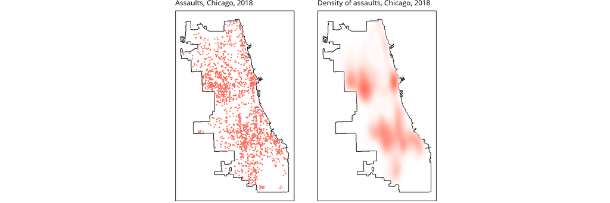

Figure 1.

```r
#-----Chicago's boundary-----
chicagoBoundary <-
  st_read(file.path(root.dir,"/Chapter5/chicagoBoundary.geojson")) %>%
  st_transform(crs)

#-----Map assaults-----
assaultsPointsPlot = ggplot()+
  geom_sf(data = chicagoBoundary, fill = NA, color = 'black') +
  geom_sf(data = sample_n(assaults2018[chicagoBoundary,], 2000), size = .5, color = color2) +
  labs(title = 'Assaults, Chicago, 2018')+
  mapTheme()+
  theme(legend.position = 'bottom',
        plot.margin = unit(c(0,0,0,16), "line"))

assaultsDensityPlot = ggplot()+
  geom_sf(data = chicagoBoundary, fill = NA, color = 'black') +
  stat_density2d(data = data.frame(st_coordinates(assaults2018[chicagoBoundary,])),
               aes(X, Y, fill = ..level.., alpha = ..level..),
               size = .01, bins = 40, geom = 'polygon') +
  scale_fill_gradient(low = color1, high = color2,
                      breaks = c(0.000000003,0.00000003),
                      labels = c('Minimum', 'Maximum'), name = 'Density') +
  scale_alpha(range = c(0.00, 0.35), guide = FALSE) +
  labs(title = 'Density of assaults, Chicago, 2018') +
  mapTheme()+
  theme(legend.position = 'bottom',
        plot.margin = unit(c(0,0,0,-16), "line"))

grid.arrange(ncol = 2,
             assaultsPointsPlot,
             assaultsDensityPlot)
```

In the following sections of this document, I build and iteratively improve a model to predict *assault* cases in Chicago based on data from 2018, until it attains reasonable accuracy and generalizability. Then, I test the model against assault observations in the next year (2019), while comparing it with the traditional kernel density method. Finally, I initiate a discussion on whether I would recommend this algorithm to be put into production.

## 2 Data & feature engineering

### 2.1 The fishnet

To facilitate modelling, a grid (fishnet) of 1500*1500-feet cells are created, and the grid cell would be the basic modelling unit. Figure 2. maps the assaults by grid cell.

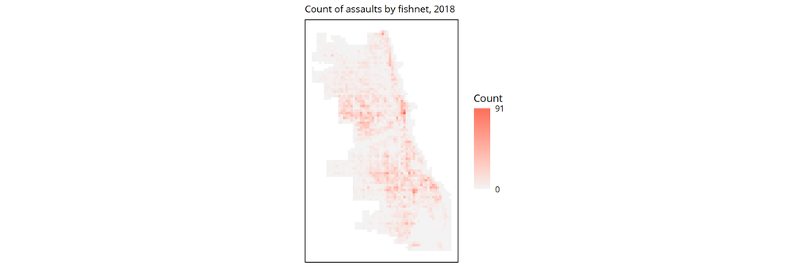

Figure 2.

```r
#-----Fishnet-----
fishnet = st_make_grid(chicagoBoundary, cellsize = 1500) %>% # Cell size 1500ft
  .[chicagoBoundary] %>%
  st_sf() %>%
  mutate(uniqueID = rownames(.))

#-----Count assaults in fishnet-----
fishnet_1 =
  dplyr::select(assaults2018) %>%
  mutate(assaultsCount = 1) %>%
  aggregate(., fishnet, sum) %>%
  mutate(assaultsCount = replace_na(assaultsCount, 0),
         cellID = rownames(.))

#---Plot assaults by grid cell-----
ggplot(data = fishnet_1) +
  geom_sf(aes(fill = assaultsCount), color = NA) +
  scale_fill_gradient(low = color1, high = color2,
                      breaks = c(0, 91),
                      labels = c(0, 91), name = 'Count')+
  labs(title = 'Count of assaults by fishnet, 2018') +
  mapTheme()
```

### 2.2 The risk factors

Next, I download and wrangle a set of risk factor features into the fishnet. Seven features are downloaded from the Chicago 311 reports of abandoned vehicles, street lights out, alley lights out, vacant buildings, sanitation complaints, potholes, and graffiti (Figure 3.). It is also reasonable to hypothesize that assaults are more likely to occur where population density and the unemployment rate are higher. Tract-level population density and unemployment rate are calculated from the ACS 5-year estimates of 2018. Another hypothesis is that assaults are spatially converged in the city center; therefore, the distant from each cell to the centroid of Loop (considered the center of Chicago) is calculated.

```r
#-----Risk factors-----

alleyLightsOut = read.socrata('https://data.cityofchicago.org/resource/up7z-t43p.json')%>%
  filter(., (!is.na(x_coordinate)) & (!is.na(y_coordinate))) %>%
  filter(., substr(creation_date, 1, 4) == '2018') %>%
  st_as_sf(coords = c('x_coordinate', 'y_coordinate'), crs = crs, agr = 'constant') %>%
  distinct() %>%
  dplyr::select(geometry) %>%
  .[chicagoBoundary,]

graffiti = read.socrata('https://data.cityofchicago.org/resource/hec5-y4x5.json')%>%
  filter(., (!is.na(x_coordinate)) & (!is.na(y_coordinate))) %>%
  filter(., substr(creation_date, 1, 4) == '2018') %>%
  st_as_sf(coords = c('x_coordinate', 'y_coordinate'), crs = crs, agr = 'constant') %>%
  distinct() %>%
  dplyr::select(geometry) %>%
  .[chicagoBoundary,]

abandonedVehicles = read.socrata('https://data.cityofchicago.org/resource/3c9v-pnva.json')%>%
  filter(., (!is.na(x_coordinate)) & (!is.na(y_coordinate))) %>%
  filter(., substr(creation_date, 1, 4) == '2018') %>%
  st_as_sf(coords = c('x_coordinate', 'y_coordinate'), crs = crs, agr = 'constant') %>%
  distinct() %>%
  dplyr::select(geometry) %>%
  .[chicagoBoundary,]

potHoles = read.socrata('https://data.cityofchicago.org/resource/_311-potholes.json')%>%
  filter(., (!is.na(x_coordinate)) & (!is.na(y_coordinate))) %>%
  filter(., substr(creation_date, 1, 4) == '2018') %>%
  st_as_sf(coords = c('x_coordinate', 'y_coordinate'), crs = crs, agr = 'constant') %>%
  distinct() %>%
  dplyr::select(geometry) %>%
  .[chicagoBoundary,]

sanitationComplaints = read.socrata('https://data.cityofchicago.org/resource/me59-5fac.json')%>%
  filter(., (!is.na(x_coordinate)) & (!is.na(y_coordinate))) %>%
  filter(., substr(creation_date, 1, 4) == '2018') %>%
  st_as_sf(coords = c('x_coordinate', 'y_coordinate'), crs = crs, agr = 'constant') %>%
  distinct() %>%
  dplyr::select(geometry) %>%
  .[chicagoBoundary,]

streetLightsOut = read.socrata('https://data.cityofchicago.org/resource/3aav-uy2v.json')%>%
  filter(., (!is.na(x_coordinate)) & (!is.na(y_coordinate))) %>%
  filter(., substr(creation_date, 1, 4) == '2018') %>%
  st_as_sf(coords = c('x_coordinate', 'y_coordinate'), crs = crs, agr = 'constant') %>%
  distinct() %>%
  dplyr::select(geometry) %>%
  .[chicagoBoundary,]

vacantBuildings = read.socrata('https://data.cityofchicago.org/resource/7nii-7srd.json')%>%
  filter(., (!is.na(x_coordinate)) & (!is.na(y_coordinate))) %>%
  filter(., substr(date_service_request_was_received, 1, 4) == '2018') %>%
  st_as_sf(coords = c('x_coordinate', 'y_coordinate'), crs = crs, agr = 'constant') %>%
  distinct() %>%
  dplyr::select(geometry) %>%
  .[chicagoBoundary,]
```

```r
#-----Get neighborhood----
neighborhoods =
  st_read("https://raw.githubusercontent.com/blackmad/neighborhoods/master/chicago.geojson") %>%
  st_transform(crs)

#-----Get ACS-----
tract = get_acs(geography = 'tract',
                variables = c('B01001_001E',
                              'B01001A_001E',
                              'B17005_001E',
                              'B17005_005E',
                              'B17005_010E',
                              'B17005_016E',
                              'B17005_021E'),
                year = 2018, state = 17, county = 031, geometry = TRUE,
                output = 'wide') %>%
  st_transform(crs) %>%
  rename(totalPopulation = B01001_001E) %>%
  mutate(area = st_area(.) %>% as.numeric(),
         density = totalPopulation * 1000000 / area,
         pctWhite = B01001A_001E / totalPopulation,
         unemploymentRate = (B17005_001E - B17005_005E -
           B17005_010E - B17005_016E - B17005_021E) / B17005_001E) %>%
  dplyr::select(-starts_with('B')) %>%
  .[chicagoBoundary,]

#-----Distance to center of loop-----
loopCenter =
  filter(neighborhoods, name == 'Loop') %>%
  st_centroid()

#-----Join ACS data to fishnet-----
fishnet_2 =
  st_centroid(fishnet_1) %>%
  st_join(dplyr::select(tract, density, pctWhite, unemploymentRate)) %>%
  st_drop_geometry()%>%
  left_join(fishnet_1) %>%
  st_sf()

#-----Assign neighborhoods-----
fishnet_3 =
  st_centroid(fishnet_2) %>%
  st_join(dplyr::select(neighborhoods, name)) %>%
  st_drop_geometry()%>%
  left_join(fishnet_2) %>%
  st_sf() %>%
  mutate(neighborhood = name)

#-----Join distance to Loop center-----
fishnet_4 = fishnet_3
fishnet_4$distLoop = st_distance(st_centroid(fishnet_3), loopCenter) %>%
  as.numeric()
```

The nine risk factors are mapped as shown in Figure 3.

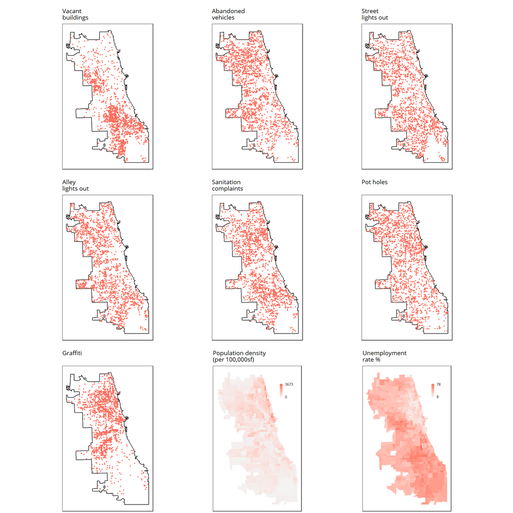

Figure 3.

```r
#-----Map all risk factors-----
vacantBuildingsPlot =
  ggplot() +
  geom_sf(data = chicagoBoundary, fill = NA, color = 'black') +
  geom_sf(data = sample_n(vacantBuildings, 2000), size = .5, color = '#FC6D5C') +
  labs(title = 'Vacant\nbuildings')+
  mapTheme2()+
  theme(plot.margin = unit(c(1,0,0,5), "line"))

abandonedVehiclesPlot =
  ggplot() +
  geom_sf(data = chicagoBoundary, fill = NA, color = 'black') +
  geom_sf(data = sample_n(abandonedVehicles, 2000), size = .5, color = '#FC6D5C') +
  labs(title = 'Abandoned\nvehicles') +
  mapTheme2()+
  theme(plot.margin = unit(c(1,0,0,0), "line"))

streetLightsOutPlot =
  ggplot() +
  geom_sf(data = chicagoBoundary, fill = NA, color = 'black') +
  geom_sf(data = sample_n(streetLightsOut, 2000), size = .5, color = '#FC6D5C') +
  labs(title = 'Street\nlights out') +
  mapTheme2()+
  theme(plot.margin = unit(c(1,0,0,-5), "line"))

alleyLightsOutPlot =
  ggplot() +
  geom_sf(data = chicagoBoundary, fill = NA, color = 'black') +
  geom_sf(data = sample_n(alleyLightsOut, 2000), size = .5, color = '#FC6D5C') +
  labs(title = 'Alley\nlights out') +
  mapTheme2()+
  theme(plot.margin = unit(c(1,0,0,5), "line"))

sanitationComplaintsPlot =
  ggplot() +
  geom_sf(data = chicagoBoundary, fill = NA, color = 'black') +
  geom_sf(data = sample_n(sanitationComplaints, 2000), size = .5, color = '#FC6D5C') +
  labs(title = 'Sanitation\ncomplaints') +
  mapTheme2()+
  theme(plot.margin = unit(c(1,0,0,0), "line"))

potHolesPlot =
  ggplot() +
  geom_sf(data = chicagoBoundary, fill = NA, color = 'black') +
  geom_sf(data = sample_n(potHoles, 2000), size = .5, color = '#FC6D5C') +
  labs(title = 'Pot holes\n ') +
  mapTheme2()+
  theme(plot.margin = unit(c(1,0,0,-5), "line"))

graffitiPlot =
  ggplot() +
  geom_sf(data = chicagoBoundary, fill = NA, color = 'black') +
  geom_sf(data = sample_n(graffiti, 2000), size = .5, color = '#FC6D5C') +
  labs(title = 'Graffiti\n ') +
  mapTheme2()+
  theme(plot.margin = unit(c(1,0,0,5), "line"))

densityPlot =
  ggplot() +
  geom_sf(data = tract %>% filter(., density < 4000),
          aes(fill = density), color = NA) +
  scale_fill_gradient(low = color1, high = color2,
                      breaks = c(0, 3673),
                      labels = c(0, 3673), name = '') +
  labs(title = 'Population density\n(per 100,000sf)') +
  # geom_sf(data = chicagoBoundary, fill = NA, color = 'black') +
  mapTheme2()+
  theme(legend.position = c(.83,.86),
        plot.margin = unit(c(1,0,0,0), "line"))


unemploymentPlot =
  ggplot() +
  geom_sf(data = tract%>% filter(., unemploymentRate < .8),
          aes(fill = 100 * unemploymentRate), color = NA) +
  scale_fill_gradient(low = color1, high = color2,
                      breaks = c(8, 78),
                      labels = c(8, 78), name = '') +
  labs(title = 'Unemployment\nrate %') +
  # geom_sf(data = chicagoBoundary, fill = NA, color = 'black') +
  mapTheme2()+
    theme(legend.position = c(.83,.86),
          plot.margin = unit(c(1,0,0,-5), "line"))


grid.arrange(ncol = 3, nrow = 3,
             vacantBuildingsPlot, abandonedVehiclesPlot, streetLightsOutPlot,
             alleyLightsOutPlot, sanitationComplaintsPlot, potHolesPlot,
             graffitiPlot, densityPlot, unemploymentPlot)
```

The *exposure* of each cell to any risk factor is calculated by averaging the distances from the cell centroid to its three nearest occurrences of the factor. Figure 4. shows the final engineered features joined to the fishnet.

```r
#-----Calculate-----

fishnet_5 =
  fishnet_4 %>%
  mutate(
    abandonedVehiclesDist = nn_function(st_coordinates(st_centroid(fishnet_4)),
                                        st_coordinates(abandonedVehicles), 3),
    vacantBuildingsDist = nn_function(st_coordinates(st_centroid(fishnet_4)),
                                      st_coordinates(vacantBuildings), 3),
    alleyLightsOutDist = nn_function(st_coordinates(st_centroid(fishnet_4)),
                                     st_coordinates(alleyLightsOut), 3),
    streetLightsOutDist = nn_function(st_coordinates(st_centroid(fishnet_4)),
                                  st_coordinates(streetLightsOut), 3),
    sanitationComplaintsDist = nn_function(st_coordinates(st_centroid(fishnet_4)),
                                           st_coordinates(sanitationComplaints), 3),
    graffitiDist = nn_function(st_coordinates(st_centroid(fishnet_4)),
                               st_coordinates(graffiti), 3),
    potHolesDist = nn_function(st_coordinates(st_centroid(fishnet_4)),
                               st_coordinates(potHoles), 3))
```

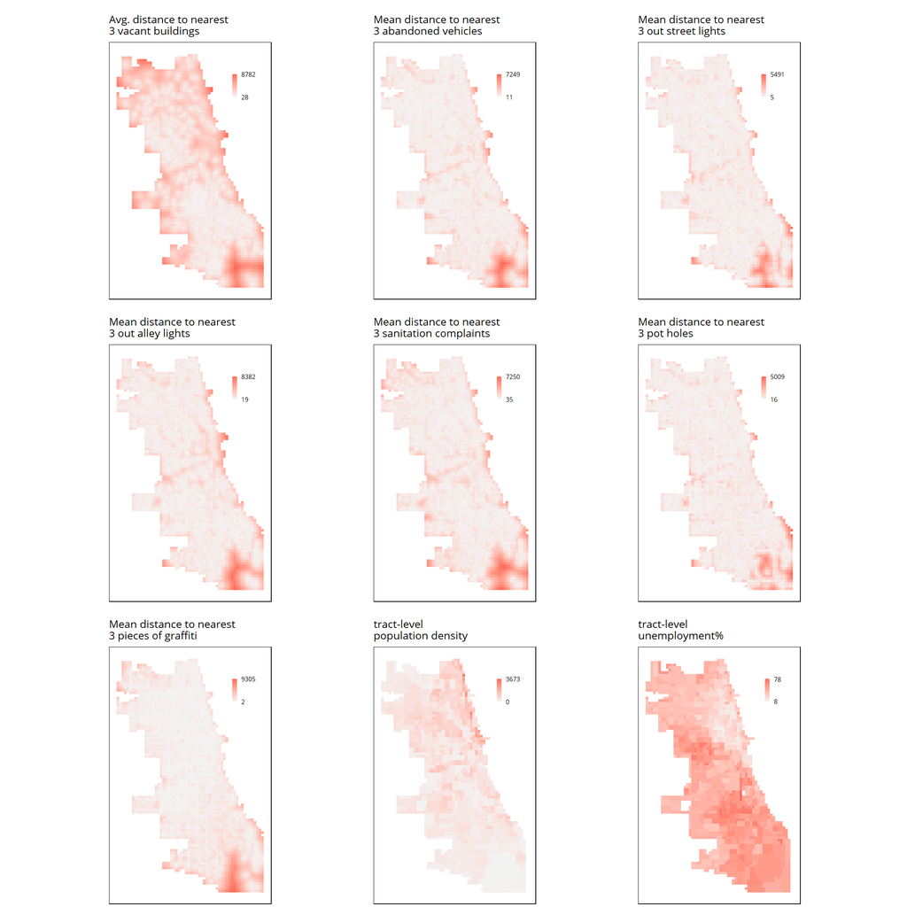

Figure 4.

```r
vacantBuildingsFishnet =
  ggplot() +
  geom_sf(data = fishnet_5, aes(fill = vacantBuildingsDist), color = NA) +
  scale_fill_gradient(low = color1, high = color2,
                      breaks = c(28, 8782),
                      labels = c(28, 8782), name = '') +
  labs(title = 'Avg. distance to nearest\n3 vacant buildings')+
  mapTheme2()+
  theme(legend.position = c(.83,.86),
        plot.margin = unit(c(1,0,0,5), "line"))

abandonedVehiclesFishnet =
  ggplot() +
  geom_sf(data = fishnet_5, aes(fill = abandonedVehiclesDist), color = NA) +
  scale_fill_gradient(low = color1, high = color2,
                      breaks = c(11, 7249),
                      labels = c(11, 7249), name = '') +
  labs(title = 'Mean distance to nearest\n3 abandoned vehicles')+
  mapTheme2()+
  theme(legend.position = c(.83,.86),
        plot.margin = unit(c(1,0,0,0), "line"))

streetLightsOutFishnet =
  ggplot() +
  geom_sf(data = fishnet_5, aes(fill = streetLightsOutDist), color = NA) +
  scale_fill_gradient(low = color1, high = color2,
                      breaks = c(5, 5491),
                      labels = c(5, 5491), name = '') +
  labs(title = 'Mean distance to nearest\n3 out street lights')+
  mapTheme2()+
  theme(legend.position = c(.83,.86),
        plot.margin = unit(c(1,0,0,-5), "line"))

alleyLightsOutFishnet =
  ggplot() +
  geom_sf(data = fishnet_5, aes(fill = alleyLightsOutDist), color = NA) +
  scale_fill_gradient(low = color1, high = color2,
                      breaks = c(19, 8382),
                      labels = c(19, 8382), name = '') +
  labs(title = 'Mean distance to nearest\n3 out alley lights')+
  mapTheme2()+
  theme(legend.position = c(.83,.86),
        plot.margin = unit(c(1,0,0,5), "line"))

sanitationComplaintsFishnet =
  ggplot() +
  geom_sf(data = fishnet_5, aes(fill = sanitationComplaintsDist), color = NA) +
  scale_fill_gradient(low = color1, high = color2,
                      breaks = c(35, 7250),
                      labels = c(35, 7250), name = '') +
  labs(title = 'Mean distance to nearest\n3 sanitation complaints')+
  mapTheme2()+
  theme(legend.position = c(.83,.86),
        plot.margin = unit(c(1,0,0,0), "line"))

potHolesFishnet =
  ggplot() +
  geom_sf(data = fishnet_5, aes(fill = potHolesDist), color = NA) +
  scale_fill_gradient(low = color1, high = color2,
                      breaks = c(16, 5009),
                      labels = c(16, 5009), name = '') +
  labs(title = 'Mean distance to nearest\n3 pot holes')+
  mapTheme2()+
  theme(legend.position = c(.83,.86),
        plot.margin = unit(c(1,0,0,-5), "line"))

graffitiFishnet =
  ggplot() +
  geom_sf(data = fishnet_5, aes(fill = graffitiDist), color = NA) +
  scale_fill_gradient(low = color1, high = color2,
                      breaks = c(2, 9305),
                      labels = c(2, 9305), name = '') +
  labs(title = 'Mean distance to nearest\n3 pieces of graffiti')+
  mapTheme2()+
  theme(legend.position = c(.83,.86),
        plot.margin = unit(c(1,0,0,5), "line"))

densityFishnet =
  ggplot() +
  geom_sf(data = fishnet_5, aes(fill = density), color = NA) +
  scale_fill_gradient(low = color1, high = color2,
                      breaks = c(0, 3673),
                      labels = c(0, 3673), name = '', na.value = 'white') +
  labs(title = 'tract-level\npopulation density')+
  mapTheme2()+
  theme(legend.position = c(.83,.86),
        plot.margin = unit(c(1,0,0,0), "line"))

unemploymentFishnet =
  ggplot() +
  geom_sf(data = fishnet_5, aes(fill = unemploymentRate * 100), color = NA) +
  scale_fill_gradient(low = color1, high = color2,
                      breaks = c(8, 78),
                      labels = c(8, 78), name = '', na.value = 'white') +
  labs(title = 'tract-level\nunemployment%')+
  mapTheme2()+
  theme(legend.position = c(.83,.86),
        plot.margin = unit(c(1,0,0,-5), "line"))


grid.arrange(ncol = 3, nrow = 3,
             vacantBuildingsFishnet, abandonedVehiclesFishnet, streetLightsOutFishnet,
             alleyLightsOutFishnet, sanitationComplaintsFishnet, potHolesFishnet,
             graffitiFishnet, densityFishnet, unemploymentFishnet)
```

Apart from the risk factors, the racial component is also downloaded from the ACS to test the model’s generalizability across different racial contexts later. Neighborhood boundaries are used for spatial leave-one-group-out cross-validation later. Finally, a unique `cvID` is created for each cell to facilitate k-fold cross-validation.

```r
fishnet_6 = fishnet_5 %>%
  mutate(cvID = sample(round(nrow(fishnet) / 29), size = nrow(fishnet),
                       replace = TRUE))
```

## 3 Spatial processes

Crimes tend to cluster in space. So far, however, each grid cell is considered to be an independent observation with certain exposure to risk factors; the spatial variation of assault occurrences is not fully accounted for. In this step, I perform a Local Moran’s I test to identify the hot spots of assaults. The results are shown in Figure 5.

```r
fishnet_7 =
  fishnet_6 %>%
  mutate(assaultsHotspotSig = localmoran(
    fishnet_6$assaultsCount,
    nb2listw(poly2nb(as_Spatial(fishnet_6), queen = TRUE),
             style = 'W',
             zero.policy = TRUE))[,5])
```

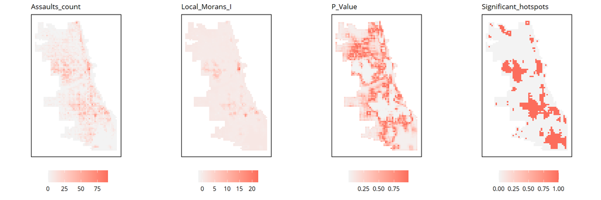

Figure 5.

```r
moranTable =
  cbind(
    as.data.frame(localmoran(
    fishnet_6$assaultsCount,
    nb2listw(poly2nb(as_Spatial(fishnet_6), queen = TRUE),
             style = 'W',
             zero.policy = TRUE))),
    as.data.frame(fishnet_6)
  ) %>%
  st_sf() %>%
  dplyr::select(Assaults_count = assaultsCount,
                Local_Morans_I = Ii,
                P_Value = `Pr(z != E(Ii))`) %>%
  mutate(Significant_hotspots = ifelse(P_Value <= 0.05, 1, 0)) %>%
  gather(Variable, Value, -geometry)

vars = unique(moranTable$Variable)
varList = list()

for(i in vars){
  varList[[i]] =
    ggplot() +
    geom_sf(data = filter(moranTable, Variable == i),
            aes(fill = Value), color = NA) +
    scale_fill_gradient(low = color1, high = color2, name = '') +
    labs(title = i) +
    mapTheme() + theme(legend.position = 'bottom')
}

do.call(grid.arrange, c(varList, ncol = 4))
```

To incorporate the spatial processes into the model, I will add the results of the Local Moran’s test as independent variables. Using the 0.01 significance threshold, I generate a dummy variable denoting whether a cell belongs to a local significant cluster. I also measure the nearest distance from each cell centroid to the nearest significant cluster.

```r
fishnet_8 = fishnet_7 %>%
  mutate(assaultsHotspotSig.01 =
           ifelse(assaultsHotspotSig <= 0.01, 1, 0)) %>%
  mutate(sigDist =
           nn_function(st_coordinates(st_centroid(fishnet_7)),
                       st_coordinates(st_centroid(
                         filter(fishnet_7, assaultsHotspotSig.01 == 1)
                       )), 1)) %>%
  na.omit()
```

## 4 Models & cross-validation

### 4.1 Correlation tests

Figure 6. shows a series of scatter-plots of `assaultsCount` as a function of the indenpendent variables above.

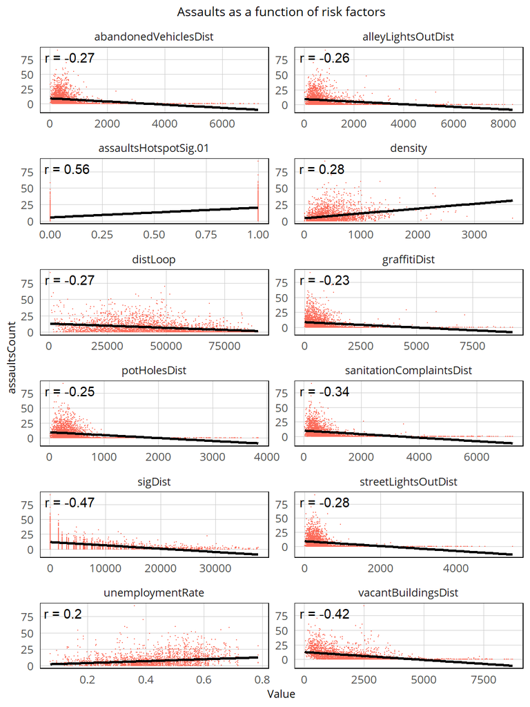

Figure 6.

```r
fishnetLong = st_drop_geometry(fishnet_8) %>%
  dplyr::select(-cellID, -pctWhite, -name, -neighborhood, -cvID, -assaultsHotspotSig) %>%
  gather(Variable, Value, -assaultsCount)

correlations = fishnetLong %>%
  group_by(Variable) %>%
  summarize(correlation = cor(Value, assaultsCount, use = 'complete.obs'))

ggplot(fishnetLong, aes(Value, assaultsCount)) +
  geom_point(size = .1, color = color2) +
  geom_text(data = correlations, aes(label = paste('r =', round(correlation, 2))),
            x = -Inf, y = Inf, vjust = 1.5, hjust = -.1) +
  geom_smooth(method = 'lm', se = FALSE, color = 'black') +
  facet_wrap(~Variable, ncol = 2, scales = 'free') +
  labs(title = 'Assaults as a function of risk factors') +
  plotTheme2()
```

### 4.2 The first model

Next, I use Poisson Regression to model the occurrences of assaults, whose distribution resembles Poisson distribution (Figure 7.).

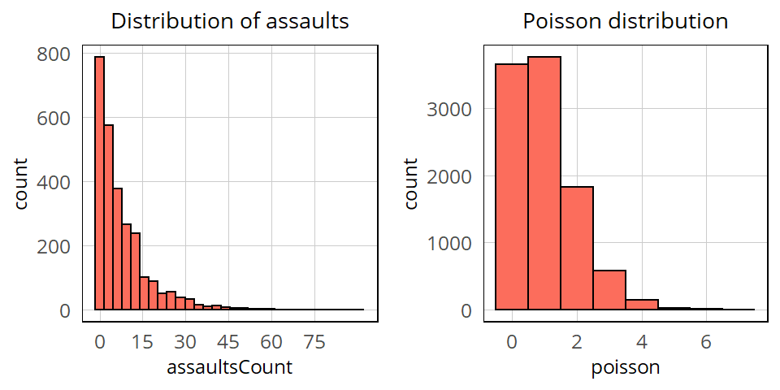

Figure 7.

```r
## Distribution of assaults
assaultsDistribution = ggplot(data = fishnet_8, aes(assaultsCount))+
  geom_histogram(bins = 30, color = 'black', fill = color2) +
  scale_x_continuous(breaks = seq(0, 80, by = 15)) +
  labs(title = 'Distribution of assaults', 2018) +
  plotTheme2()

## A regular poisson distribution
set.seed(123)
poisson = as.data.frame(rpois(10000, 1))
names(poisson)[1] = 'poisson'
poissonDistribution = ggplot(data = poisson,
                             aes(poisson)) +
  geom_histogram(bins = 8, color = 'black', fill = color2) +
  labs(title = 'Poisson distribution')+
  plotTheme2()

grid.arrange(ncol = 2, assaultsDistribution, poissonDistribution)
```

Two cross-validation methods are used. The first, K-fold validation, divides the data into k (in this case, 100) folds, each of which takes turns to be the test set, and the model trained on the rest of the data is tested on this fold. The second method is the spatial leave-one-group-out (LOGO) cross-validation, which assumes a neighborhood can take advantage of the experiences of other neighborhoods. Each time, the train set leaves one neighborhood out, and then the model is tested for its generalizability on the remaining neighborhood.

```r
regVars1 = c('abandonedVehiclesDist',
             'vacantBuildingsDist',
             'alleyLightsOutDist',
             'streetLightsOutDist',
             'sanitationComplaintsDist',
             'graffitiDist',
             'potHolesDist',
             'distLoop',
             'assaultsHotspotSig.01',
             'sigDist')
## K-fold CV
reg1KFoldCV = crossValidate(
  dataset = fishnet_8,
  id = 'cvID',
  dependentVariable = 'assaultsCount',
  indVariables = regVars1
) %>%
  dplyr::select(fold = cvID,
                observation = assaultsCount,
                prediction = Prediction,
                geometry)%>%
  mutate(., error = prediction - observation)

## Spatial LOGO CV
reg1SpatialCV = crossValidate(
  dataset = fishnet_8,
  id = 'name',
  dependentVariable = 'assaultsCount',
  indVariables = regVars1
) %>%
  dplyr::select(fold = name,
                observation = assaultsCount,
                prediction = Prediction,
                geometry)%>%
  mutate(., error = prediction - observation)

## K-fold cross-validation
error1KFoldCV =
  reg1KFoldCV %>%
  group_by(fold) %>%
  summarize(meanObs = mean(observation, na.rm = TRUE),
            meanError = mean(error, na.rm = TRUE),
            meanAbsError = mean(abs(error), na.rm = TRUE),
            sdMeanAbsError = sd(abs(error), na.rm = TRUE)) %>%
  ungroup() %>%
  st_drop_geometry() %>%
  as.data.frame()

# Spatial LOGO cross-validation
error1SpatialCV =
  reg1SpatialCV %>%
  group_by(fold) %>%
  summarize(meanObs = mean(observation, na.rm = TRUE),
            meanError = mean(error, na.rm = TRUE),
            meanAbsError = mean(abs(error), na.rm = TRUE),
            sdMeanAbsError = sd(abs(error), na.rm = TRUE)) %>%
  ungroup() %>%
  st_drop_geometry() %>%
  as.data.frame() %>%
  left_join(dplyr::select(neighborhoods, name, geometry),
            by = c('fold' = 'name')) %>%
  st_sf()
```

Figure 8. shows the model errors by random k-fold and spatial LOGO cross-validation, and Table 1. shows the means and standard errors of the MAE.

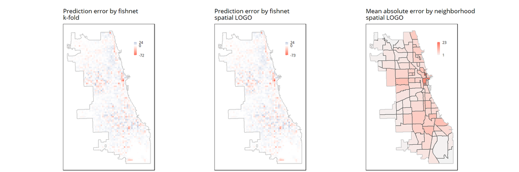

Figure 8.

```r
kFoldErrorMap1 = ggplot(data = reg1KFoldCV) +
  geom_sf(aes(fill = error), color = NA) +
  scale_fill_gradient2(low = color2, high = color3,
                      midpoint = 0, name = '',
                      breaks = c(-72, 0, 24), labels = c(-72, 0, 24))+
  geom_sf(data = chicagoBoundary, fill = NA, color = 'grey')+
  labs(title = 'Prediction error by fishnet\nk-fold')+
  mapTheme2()+
  theme(legend.position = c(.83,.86),
        plot.margin = unit(c(1,0,0,5), "line"))

spatialLogoErrorMap1 = ggplot(data = reg1SpatialCV) +
  geom_sf(aes(fill = error), color = NA) +
  scale_fill_gradient2(low = color2, high = color3,
                      midpoint = 0, name = '',
                      breaks = c(-73, 0, 24), labels = c(-73, 0, 24))+
  geom_sf(data = chicagoBoundary, fill = NA, color = 'grey')+
  labs(title = 'Prediction error by fishnet\nspatial LOGO')+
  mapTheme2()+
  theme(legend.position = c(.83,.86),
        plot.margin = unit(c(1,0,0,0), "line"))

spatialLogoErrorByNhMap1 = ggplot(data = error1SpatialCV) +
  geom_sf(aes(fill = meanAbsError)) +
  scale_fill_gradient(low = color1, high = color2,
                      name = '',
                      breaks = c(1, 23),
                      labels = c(1, 23)) +
  geom_sf(data = chicagoBoundary, fill = NA, color = 'grey') +
  labs(title = 'Mean absolute error by neighborhood\nspatial LOGO')+
  mapTheme2()+
  theme(legend.position = c(.83,.86),
        plot.margin = unit(c(1,0,0,-5), "line"))

grid.arrange(ncol = 3, kFoldErrorMap1, spatialLogoErrorMap1, spatialLogoErrorByNhMap1)
```

```r
twoRegs = rbind(
  error1KFoldCV %>% mutate(regression = 'Random k-fold CV'),
  error1SpatialCV %>% st_drop_geometry() %>% mutate(regression = 'Spatial LOGO CV')
)

errorSummary1 = twoRegs %>%
  group_by(regression)%>%
  summarize(Mean_of_MAE = round(mean(meanAbsError), 2),
            Standard_error_of_MAE = round(sd(meanAbsError), 2))

kable(errorSummary1, caption = '<center><small><small>Table 1.</small></small></center>') %>%
    kable_classic(full_width = FALSE,
                  html_font = 'Open Sans',
                  position = 'center',
                  font_size = 11)%>%
  gsub("font-size: initial !important;",
         "font-size: 10pt !important;",
         .)
```

Table 1.

| regression | Mean_of_MAE | Standard_error_of_MAE |
| --- | --- | --- |
| Random k-fold CV | 4.22 | 1.09 |
| Spatial LOGO CV | 4.87 | 3.36 |

The mapping of prediction errors reveal major underestimations in some parts of Chicago, e.g. the urban cores. Figure 9. shows that the random k-fold cross-validation produces more accurate results than the spatial LOGO cross-validation. This means that there is strong spatial variation between neighborhoods; the experience of some neighborhoods may not be well generalized into other neighborhoods, especially those where assaults are more frequent.

This could mean either a flaw in the prediction model, or reflects a selection bias of assault reports, because assaults may be more likely to be reported in urban cores. I will come back to the issue at the end of this document.

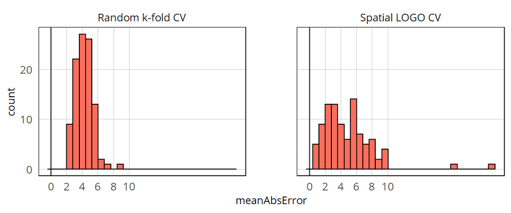

Figure 9.

```r
errorPlot1 = ggplot(data = twoRegs, aes(meanAbsError)) +
  geom_histogram(bins = 30, color = 'black', fill = color2) +
  facet_wrap(~regression) +
  geom_vline(xintercept = 0) +
  scale_x_continuous(breaks = seq(0, 10, by = 2)) +
  plotTheme2()+
  theme(panel.spacing = unit(3, 'lines'))

errorPlot1
```

## 5 Accounting for high outliers

In the last section, although I have added the hot spots of assaults into the model, it still fails to account for very high assault occurrences in some parts of Chicago, especially in the urban cores.

In this section, I intend to improve prediction accuracy by accounting for these high outliers. The improved models divides the fishnet into quintiles based on the frequency of assaults and add this as an independent variable.

### 5.1 Using assault quintiles

```r
fishnet_9 = fishnet_8 %>%
  mutate(assaultsCount5Tile = ntile(assaultsCount, 5) %>% as.character())
```

```r
regVars2 = c('abandonedVehiclesDist',
             'vacantBuildingsDist',
             'alleyLightsOutDist',
             'streetLightsOutDist',
             'sanitationComplaintsDist',
             'graffitiDist',
             'potHolesDist',
             'distLoop',
             'assaultsHotspotSig.01',
             'sigDist',
             'assaultsCount5Tile')
## K-fold CV
reg2KFoldCV = crossValidate(
  dataset = fishnet_9,
  id = 'cvID',
  dependentVariable = 'assaultsCount',
  indVariables = regVars2
) %>%
  dplyr::select(fold = cvID,
                observation = assaultsCount,
                prediction = Prediction,
                geometry)%>%
  mutate(., error = prediction - observation)

## Spatial LOGO CV
reg2SpatialCV = crossValidate(
  dataset = fishnet_9,
  id = 'name',
  dependentVariable = 'assaultsCount',
  indVariables = regVars2
) %>%
  dplyr::select(fold = name,
                observation = assaultsCount,
                prediction = Prediction,
                geometry)%>%
  mutate(., error = prediction - observation)

## K-fold cross-validation
error2KFoldCV =
  reg2KFoldCV %>%
  group_by(fold) %>%
  summarize(meanObs = mean(observation, na.rm = TRUE),
            meanError = mean(error, na.rm = TRUE),
            meanAbsError = mean(abs(error), na.rm = TRUE),
            sdMeanAbsError = sd(abs(error), na.rm = TRUE)) %>%
  ungroup() %>%
  st_drop_geometry() %>%
  as.data.frame()

# Spatial LOGO cross-validation
error2SpatialCV =
  reg2SpatialCV %>%
  group_by(fold) %>%
  summarize(meanObs = mean(observation, na.rm = TRUE),
            meanError = mean(error, na.rm = TRUE),
            meanAbsError = mean(abs(error), na.rm = TRUE),
            sdMeanAbsError = sd(abs(error), na.rm = TRUE)) %>%
  ungroup() %>%
  st_drop_geometry() %>%
  as.data.frame() %>%
  left_join(dplyr::select(neighborhoods, name, geometry),
            by = c('fold' = 'name')) %>%
  st_sf()
```

Figure 10. shows the model errors by random k-fold and spatial LOGO cross-validation, and Table 2. shows the means and standard errors of the MAE.

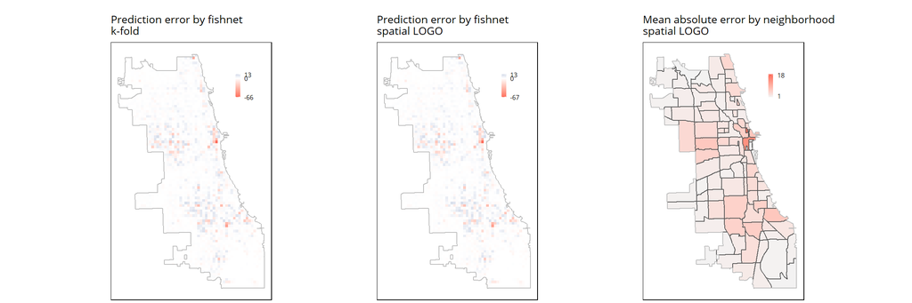

Figure 10.

```r
kFoldErrorMap2 = ggplot(data = reg2KFoldCV) +
  geom_sf(aes(fill = error), color = NA) +
  scale_fill_gradient2(low = color2, high = color3,
                      midpoint = 0, name = '',
                      breaks = c(-66, 0, 13), labels = c(-66, 0, 13))+
  geom_sf(data = chicagoBoundary, fill = NA, color = 'grey')+
  labs(title = 'Prediction error by fishnet\nk-fold')+
  mapTheme2()+
  theme(legend.position = c(.83,.86),
        plot.margin = unit(c(1,0,0,5), "line"))

spatialLogoErrorMap2 = ggplot(data = reg2SpatialCV) +
  geom_sf(aes(fill = error), color = NA) +
  scale_fill_gradient2(low = color2, high = color3,
                      midpoint = 0, name = '',
                      breaks = c(-67, 0, 13), labels = c(-67, 0, 13))+
  geom_sf(data = chicagoBoundary, fill = NA, color = 'grey')+
  labs(title = 'Prediction error by fishnet\nspatial LOGO')+
  mapTheme2()+
  theme(legend.position = c(.83,.86),
        plot.margin = unit(c(1,0,0,0), "line"))

spatialLogoErrorByNhMap2 = ggplot(data = error2SpatialCV) +
  geom_sf(aes(fill = meanAbsError)) +
  scale_fill_gradient(low = color1, high = color2,
                      name = '',
                      breaks = c(1, 18),
                      labels = c(1, 18)) +
  geom_sf(data = chicagoBoundary, fill = NA, color = 'grey') +
  labs(title = 'Mean absolute error by neighborhood\nspatial LOGO')+
  mapTheme2()+
  theme(legend.position = c(.83,.86),
        plot.margin = unit(c(1,0,0,-5), "line"))

grid.arrange(ncol = 3, kFoldErrorMap2, spatialLogoErrorMap2, spatialLogoErrorByNhMap2)
```

```r
twoRegs2 = rbind(
  error2KFoldCV %>% mutate(regression = 'Random k-fold CV'),
  error2SpatialCV %>% st_drop_geometry() %>% mutate(regression = 'Spatial LOGO CV')
)

errorSummary2 = twoRegs2 %>%
  group_by(regression)%>%
  summarize(Mean_of_MAE = round(mean(meanAbsError), 2),
            Standard_error_of_MAE = round(sd(meanAbsError), 2))

kable(errorSummary2, caption = '<center><small><small>Table 2.</small></small></center>') %>%
    kable_classic(full_width = FALSE,
                  html_font = 'Open Sans',
                  position = 'center',
                  font_size = 11)%>%
  gsub("font-size: initial !important;",
         "font-size: 10pt !important;",
         .)
```

Table 2.

| regression | Mean_of_MAE | Standard_error_of_MAE |
| --- | --- | --- |
| Random k-fold CV | 2.02 | 0.84 |
| Spatial LOGO CV | 2.25 | 2.61 |

Compared to the first model, incorporating assault frequency quintiles has reduced the spatial variation of errors. The histogram of prediction errors as shown in Figure 11. has confirmed a major improvement regarding mean MAE. However, the new model still underestimates assaults the urban cores.

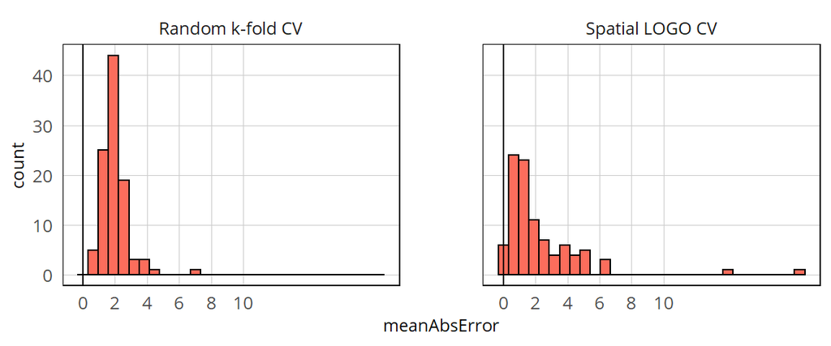

Figure 11.

```r
errorPlot2 = ggplot(data = twoRegs2, aes(meanAbsError)) +
  geom_histogram(bins = 30, color = 'black', fill = color2) +
  facet_wrap(~regression) +
  geom_vline(xintercept = 0) +
  scale_x_continuous(breaks = seq(0, 10, by = 2)) +
  plotTheme2()+
  theme(panel.spacing = unit(3, 'lines'))

errorPlot2
```

Figure 12. shows the difference between predicted and observed assaults of the original and improved model using random k-fold and spatial LOGO cross-validation. The improved model is more accurate regarding cells with frequent assault occurrences. However, it is *overestimating* for the ninth decile and *underestimating* the tenth decile. It could be that the difference between the ninth and tenth deciles is so large, that the quintile classification is insufficient.

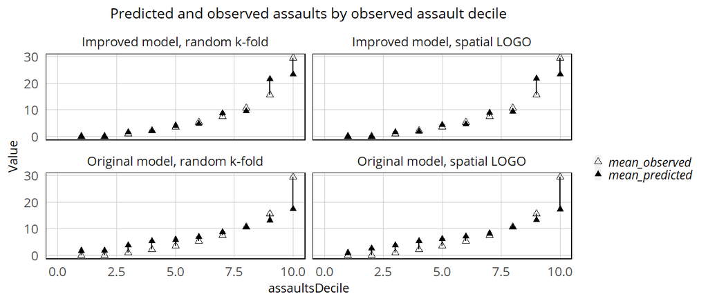

Figure 12.

```r
fourRegs = rbind(reg1KFoldCV %>% mutate(Regression = 'Original model, random k-fold'),
                 reg1SpatialCV %>% mutate(Regression = 'Original model, spatial LOGO'),
                 reg2KFoldCV %>% mutate(Regression = 'Improved model, random k-fold'),
                 reg2SpatialCV %>% mutate(Regression = 'Improved model, spatial LOGO'))

st_drop_geometry(fourRegs) %>%
  group_by(Regression) %>%
  mutate(assaultsDecile = ntile(observation, 10)) %>%
  group_by(Regression, assaultsDecile) %>%
  summarize(mean_observed = mean(observation, na.rm = T),
            mean_predicted = mean(prediction, na.rm = T)) %>%
  gather(Variable, Value, -Regression, -assaultsDecile) %>%
  ggplot(aes(assaultsDecile, Value, shape = Variable)) +
  geom_point(size = 1.5) +
  geom_path(aes(group = assaultsDecile), color = 'black') +
  scale_shape_manual(values = c(2, 17), name = '') +
  facet_wrap(~Regression) +
  xlim(0, 10) +
  labs(title = 'Predicted and observed assaults by observed assault decile') +
  plotTheme2()
```

### 5.2 Using assault deciles

Therefore, I further modify the model by dividing the cells into deciles instead of quintiles. Also, I further divide the cells into two classes—urban core and non-urban core.

```r
fishnet_10 = fishnet_8 %>%
  mutate(assaultsCount10Tile = ntile(assaultsCount, 10) %>% as.character())%>%
  mutate(isCore = ifelse(neighborhood == 'Loop' | neighborhood == 'Rush & Division',
                         1, 0))
```

```r
regVars3 = c('abandonedVehiclesDist',
             'vacantBuildingsDist',
             'alleyLightsOutDist',
             'streetLightsOutDist',
             'sanitationComplaintsDist',
             'graffitiDist',
             'potHolesDist',
             'distLoop',
             'assaultsHotspotSig.01',
             'sigDist',
             'assaultsCount10Tile',
             'isCore')
## K-fold CV
reg3KFoldCV = crossValidate(
  dataset = fishnet_10,
  id = 'cvID',
  dependentVariable = 'assaultsCount',
  indVariables = regVars3
) %>%
  dplyr::select(fold = cvID,
                observation = assaultsCount,
                prediction = Prediction,
                geometry)%>%
  mutate(., error = prediction - observation)

## Spatial LOGO CV
reg3SpatialCV = crossValidate(
  dataset = fishnet_10,
  id = 'name',
  dependentVariable = 'assaultsCount',
  indVariables = regVars3
) %>%
  dplyr::select(fold = name,
                observation = assaultsCount,
                prediction = Prediction,
                geometry)%>%
  mutate(., error = prediction - observation)

## K-fold cross-validation
error3KFoldCV =
  reg3KFoldCV %>%
  group_by(fold) %>%
  summarize(meanObs = mean(observation, na.rm = TRUE),
            meanError = mean(error, na.rm = TRUE),
            meanAbsError = mean(abs(error), na.rm = TRUE),
            sdMeanAbsError = sd(abs(error), na.rm = TRUE)) %>%
  ungroup() %>%
  st_drop_geometry() %>%
  as.data.frame()

# Spatial LOGO cross-validation
error3SpatialCV =
  reg3SpatialCV %>%
  group_by(fold) %>%
  summarize(meanObs = mean(observation, na.rm = TRUE),
            meanError = mean(error, na.rm = TRUE),
            meanAbsError = mean(abs(error), na.rm = TRUE),
            sdMeanAbsError = sd(abs(error), na.rm = TRUE)) %>%
  ungroup() %>%
  st_drop_geometry() %>%
  as.data.frame() %>%
  left_join(dplyr::select(neighborhoods, name, geometry),
            by = c('fold' = 'name')) %>%
  st_sf()
```

Figure 13. shows the model errors by random k-fold and spatial LOGO cross-validation, and Table 3. shows the means and standard errors of the MAE.

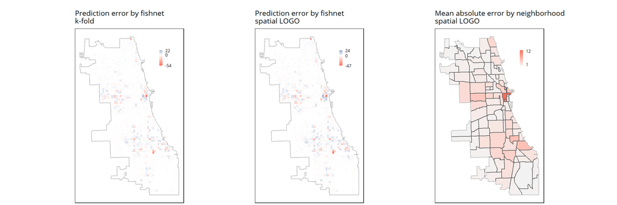

Figure 13.

```r
kFoldErrorMap3 = ggplot(data = reg3KFoldCV) +
  geom_sf(aes(fill = error), color = NA) +
  scale_fill_gradient2(low = color2, high = color3,
                      midpoint = 0, name = '',
                      breaks = c(-54, 0, 22), labels = c(-54, 0, 22))+
  geom_sf(data = chicagoBoundary, fill = NA, color = 'grey')+
  labs(title = 'Prediction error by fishnet\nk-fold')+
  mapTheme2()+
  theme(legend.position = c(.83,.86),
        plot.margin = unit(c(1,0,0,5), "line"))

spatialLogoErrorMap3 = ggplot(data = reg3SpatialCV) +
  geom_sf(aes(fill = error), color = NA) +
  scale_fill_gradient2(low = color2, high = color3,
                      midpoint = 0, name = '',
                      breaks = c(-47, 0, 24), labels = c(-47, 0, 24))+
  geom_sf(data = chicagoBoundary, fill = NA, color = 'grey')+
  labs(title = 'Prediction error by fishnet\nspatial LOGO')+
  mapTheme2()+
  theme(legend.position = c(.83,.86),
        plot.margin = unit(c(1,0,0,0), "line"))

spatialLogoErrorByNhMap3 = ggplot(data = error3SpatialCV) +
  geom_sf(aes(fill = meanAbsError)) +
  scale_fill_gradient(low = color1, high = color2,
                      name = '',
                      breaks = c(1, 12),
                      labels = c(1, 12)) +
  geom_sf(data = chicagoBoundary, fill = NA, color = 'grey') +
  labs(title = 'Mean absolute error by neighborhood\nspatial LOGO')+
  mapTheme2()+
  theme(legend.position = c(.83,.86),
        plot.margin = unit(c(1,0,0,-5), "line"))

grid.arrange(ncol = 3, kFoldErrorMap3, spatialLogoErrorMap3, spatialLogoErrorByNhMap3)
```

```r
twoRegs3 = rbind(
  error3KFoldCV %>% mutate(regression = 'Random k-fold CV'),
  error3SpatialCV %>% st_drop_geometry() %>% mutate(regression = 'Spatial LOGO CV')
)

errorSummary3 = twoRegs3 %>%
  group_by(regression)%>%
  summarize(Mean_of_MAE = round(mean(meanAbsError), 2),
            Standard_error_of_MAE = round(sd(meanAbsError), 2))

kable(errorSummary3, caption = '<center><small><small>Table 3.</small></small></center>') %>%
    kable_classic(full_width = FALSE,
                  html_font = 'Open Sans',
                  position = 'center',
                  font_size = 11)%>%
  gsub("font-size: initial !important;",
         "font-size: 10pt !important;",
         .)
```

Table 3.

| regression | Mean_of_MAE | Standard_error_of_MAE |
| --- | --- | --- |
| Random k-fold CV | 1.20 | 0.66 |
| Spatial LOGO CV | 1.24 | 1.66 |

The histogram of prediction errors are shown in Figure 14. This time, the accuracy of the model has again much improved. But the neighborhood of Loop (central Chicago) is still underestimated for its record of assault cases.

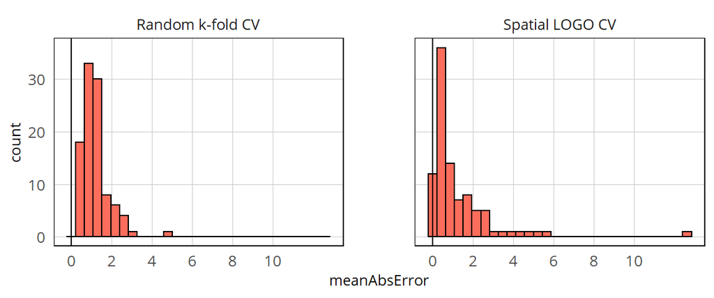

Figure 14.

```r
errorPlot3 = ggplot(data = twoRegs3, aes(meanAbsError)) +
  geom_histogram(bins = 30, color = 'black', fill = color2) +
  facet_wrap(~regression) +
  geom_vline(xintercept = 0) +
  scale_x_continuous(breaks = seq(0, 10, by = 2)) +
  plotTheme2()+
  theme(panel.spacing = unit(3, 'line'))

errorPlot3
```

Figure 15. shows the difference between predicted and observed assaults of newest model using random k-fold and spatial LOGO cross-validation. It confirms that the mean predicted and observed assault cases are nearly identical for each decile, suggesting that model accuracy has much improved.

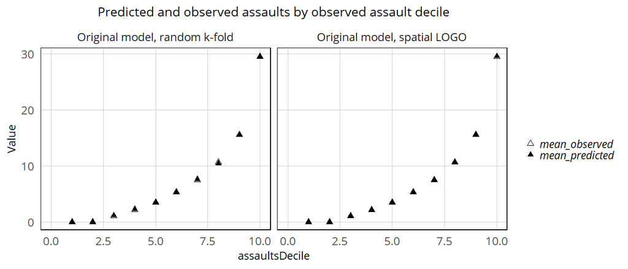

Figure 15.

```r
twoRegs3.1 = rbind(reg3KFoldCV %>% mutate(Regression = 'Original model, random k-fold'),
                 reg3SpatialCV %>% mutate(Regression = 'Original model, spatial LOGO'))

st_drop_geometry(twoRegs3.1) %>%
  group_by(Regression) %>%
  mutate(assaultsDecile = ntile(observation, 10)) %>%
  group_by(Regression, assaultsDecile) %>%
  summarize(mean_observed = mean(observation, na.rm = T),
            mean_predicted = mean(prediction, na.rm = T)) %>%
  gather(Variable, Value, -Regression, -assaultsDecile) %>%
  ggplot(aes(assaultsDecile, Value, shape = Variable)) +
  geom_point(size = 1.5) +
  geom_path(aes(group = assaultsDecile), color = 'black') +
  scale_shape_manual(values = c(2, 17), name = '') +
  facet_wrap(~Regression) +
  xlim(0, 10) +
  labs(title = 'Predicted and observed assaults by observed assault decile') +
  plotTheme2()
```

## 6 Model generalizability

### 6.1 Across racial contexts

Now, I test whether the model generalizes across different neighborhood context. I divide all the census tracts into two groups: majority white and majority non-white tracts (Figure 16.).

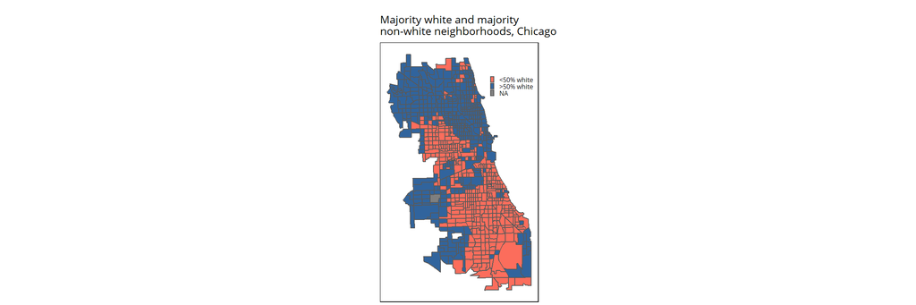

Figure 16.

```r
tractRace = tract %>%
  mutate(raceContext = ifelse(pctWhite > .5,
                              'Majority_white',
                              'Majority_non_white')) %>%
  dplyr::select(raceContext, geometry) %>%
  .[neighborhoods,]

ggplot()+
  geom_sf(data = tractRace, aes(fill = raceContext))+
  scale_fill_manual(values = c(color2, color3),
                    labels = c('<50% white', '>50% white'),
                    name = '')+
  labs(title = 'Majority white and majority\nnon-white neighborhoods, Chicago')+
  mapTheme2()+
  theme(legend.position = c(.83,.86),
        plot.margin = unit(c(1,0,0,0), "line"))
```

```r
rbind(reg3KFoldCV %>% mutate(regression = 'k_fold') %>% dplyr::select(-fold),
      reg3SpatialCV %>% mutate(regression = 'spatial_LOGO') %>% dplyr::select(-fold)
  ) %>%
  st_centroid() %>%
  st_join(tractRace) %>%
  na.omit() %>%
  st_drop_geometry() %>%
  group_by(regression, raceContext) %>%
  summarize(meanError = mean(error, na.rm = T)) %>%
  spread(raceContext, meanError) %>%
  kable(caption = '<center><small><small>Table 4.</small></small></center>') %>%
  kable_classic(full_width = FALSE,
                  html_font = 'Open Sans',
                  position = 'center',
                  font_size = 11) %>%
  gsub("font-size: initial !important;",
         "font-size: 10pt !important;",
         .)
```

Table 4.

| regression | Majority_non_white | Majority_white |
| --- | --- | --- |
| k_fold | -0.0282433 | 0.0331700 |
| spatial_LOGO | -0.0305678 | 0.0616562 |

### 6.2 Across time

As a final step, I use the model from 2018 to test on assault records in 2019, testing its generalizability across time. In doing so, I compare this model with the traditional method based on kernel density. Based on assault predictions in 2018, I use the kernel density model and this risk prediction model to divide Chicago into five risk categories. By overlaying the risk category map with the observed assaults in 2019, it is evident that the risk prediction model is more accurate in predicting assaults (Figure 17.).

```r
#-----Download crime 2019-----
allCrimes2019 = read.socrata("https://data.cityofchicago.org/resource/w98m-zvie.json") %>%
  filter(., (!is.na(x_coordinate)) & (!is.na(y_coordinate))) %>%
  st_as_sf(coords = c('x_coordinate', 'y_coordinate'), crs = crs, agr = 'constant') %>%
  distinct() %>% #Unit is feet
  dplyr::select(primary_type, description)

assaults2019 = allCrimes2019 %>% filter(., primary_type == 'ASSAULT') %>%
  dplyr::select(-primary_type, -description) %>%
  mutate(type = 'Assault')
```

```r
#-----Use kernel density to predict-----

assaultsPPP = as.ppp(st_coordinates(assaults2018), W = st_bbox(fishnet_10))
assaultsKD = density.ppp(assaultsPPP, 3000)

#-----Compare prediction with observation-----
assaultsKDE = as.data.frame(assaultsKD) %>%
  st_as_sf(coords = c('x', 'y'), crs = crs) %>%
  aggregate(., fishnet_10, mean) %>%
  mutate(label = 'Kernel Density',
         riskCategory = ntile(value, 5)) %>%
  cbind(
    aggregate(
      dplyr::select(assaults2019) %>% mutate(assaultsCount2019 = 1),., sum) %>%
      mutate(assaultsCount2019 = replace_na(assaultsCount2019, 0))
  ) %>%
  dplyr::select(label, riskCategory, assaultsCount2019)

#-----Use risk prediction to predict-----

assaultsRisk = reg3SpatialCV %>%
  mutate(label = 'Risk Predictions',
         riskCategory = ntile(prediction, 5)) %>%
  cbind(
    aggregate(
      dplyr::select(assaults2019) %>% mutate(assaultsCount2019 = 1),., sum) %>%
      mutate(assaultsCount2019 = replace_na(assaultsCount2019, 0))
    ) %>%
  dplyr::select(label, riskCategory, assaultsCount2019)
```

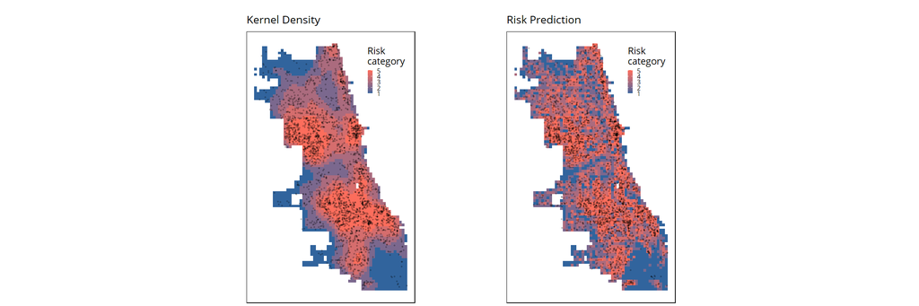

Figure 17.

```r
kernelDensityPlot = ggplot(data = assaultsKDE)+
  geom_sf(aes(fill = riskCategory), color = NA)+
  scale_fill_gradient(low = color3, high = color2, name = 'Risk\ncategory')+
  labs(title = 'Kernel Density')+
  mapTheme2()+
  theme(legend.position = c(.83,.86),
        plot.margin = unit(c(1,0,0,13), "line"))+
  geom_sf(data = sample_n(assaults2019[chicagoBoundary,], 3000), size = .3, color = 'black', alpha = .2)

riskPredictionPlot = ggplot(data = assaultsRisk)+
  geom_sf(aes(fill = riskCategory), color = NA)+
  scale_fill_gradient(low = color3, high = color2, name = 'Risk\ncategory')+
  labs(title = 'Risk Prediction')+
  mapTheme2()+
  theme(legend.position = c(.83,.86),
        plot.margin = unit(c(1,0,0,-13), "line"))+
  geom_sf(data = sample_n(assaults2019[chicagoBoundary,], 3000), size = .3, color = 'black', alpha = .2)

grid.arrange(ncol = 2, kernelDensityPlot, riskPredictionPlot)
```

Figure 18. plots the ratio of observed assaults in 2019 happening in the five risk-category areas as defined by the kernel density model and the risk prediction model. The risk prediction model as developed in this document seems to have an advantage by successfully forecasting more assaults in its high-risk zones. Therefore, the risk prediction model here may be better than the traditional kernel-density method.

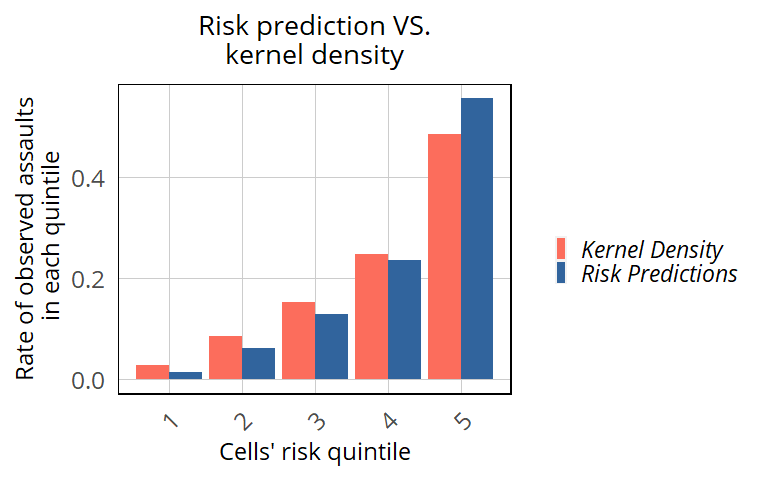

Figure 18.

```r
rbind(assaultsKDE, assaultsRisk) %>%
  st_set_geometry(NULL) %>% na.omit() %>%
  gather(Variable, Value, -label, -riskCategory) %>%
  group_by(label, riskCategory) %>%
  summarize(assaultsCount2019 = sum(Value)) %>%
  ungroup() %>%
  group_by(label) %>%
  mutate(Rate_of_test_set_crimes = assaultsCount2019 / sum(assaultsCount2019)) %>%
  ggplot(aes(riskCategory, Rate_of_test_set_crimes)) +
  geom_bar(aes(fill = label), position = 'dodge', stat = 'identity') +
  scale_fill_manual(values = c(color2, color3), name = '')+
  labs(title = 'Risk prediction VS.\nkernel density') +
  xlab('Cells\' risk quintile')+
  ylab('Rate of observed assaults\n in each quintile')+
  plotTheme2() +
  theme(axis.text.x = element_text(angle = 45, vjust = 0.5))
```

## 7 Closing remarks

In this project, I have developed a risk-prediction model to forecast crimes (assaults) in Chicago. By iteratively improving the model, I have been able to predict assaults more accurately than the traditional hot-spot method, especially in terms of accounting for very high assault occurrences in Chicago’s urban cores. This suggests that the risk-prediction method, or predictive policing, is a powerful planning tool.

Nevertheless, I would hesitate to recommend my algorithm to be put into production. As mentioned earlier, the records of assaults are likely to suffer from selection bias, in which assaults are more likely to be recorded in central urban areas. Should this be the case, then it would explain the intense convergence of assaults in central area. In this scenario, my model would only be able to predict assault *records* rather than *actual assault risks*, and it would lead probably lead to unfair outcomes such as “broken windows policing”. The selection bias of assaults should be more closely examined.